# Meta-Analytic Structural Equation Modeling

Mike Cheung

8-10 Feb 2023 (Day 3, Session 1)

# Examples and applications

## Example 1: A Five-Factor model (further analysis 1)

- We use the built-in dataset, so we do not need to reread it.
- Digman (1997) argued that these two latent factors were independent. Do the data support it?
- We may compare the model with the constraint (correlation=0) vs. the model without the constraint (correlation≠0) by a chi-square difference test.
  - $H_0: \rho=0$ vs. $H_1: \rho \neq 0$
  - We reject the null hypothesis and prefer the model without the constraint if the p-value is equal to or smaller than .05.
  - We do not reject the null hypothesis and prefer the model with the constraint if the p-value is larger than .05.
- Result shows that $\Delta\chi^2(1)=72.86, p<.0001$. Therefore, the latent factors are not independent.

```r
library(metaSEM)

## Stage 1 analysis
random1 <- tssem1(Digman97$data, Digman97$n, method="REM", RE.type="Diag")

## Model with correlated factors
model1 <- "## Alpha is measured by A, C, and ES
           Alpha =~ A + C + ES
           ## Beta is measured by E and I
           Beta =~ E + I
           ## Factor correlation between Alpha and Beta
           Alpha ~~ Beta"

RAM1 <- lavaan2RAM(model1, obs.variables=c("A","C","ES","E","I"))
RAM1
```

```
## $A
##       A   C   ES  E   I   Alpha           Beta
## A     "0" "0" "0" "0" "0" "0.1*AONAlpha"  "0"
## C     "0" "0" "0" "0" "0" "0.1*CONAlpha"  "0"
## ES    "0" "0" "0" "0" "0" "0.1*ESONAlpha" "0"
## E     "0" "0" "0" "0" "0" "0"             "0.1*EONBeta"
## I     "0" "0" "0" "0" "0" "0"             "0.1*IONBeta"
## Alpha "0" "0" "0" "0" "0" "0"             "0"
## Beta  "0" "0" "0" "0" "0" "0"             "0"
##
## $S
##       A            C            ES             E            I
## A     "0.5*AWITHA" "0"          "0"            "0"          "0"
## C     "0"          "0.5*CWITHC" "0"            "0"          "0"
## ES    "0"          "0"          "0.5*ESWITHES" "0"          "0"
## E     "0"          "0"          "0"            "0.5*EWITHE" "0"
## I     "0"          "0"          "0"            "0"          "0.5*IWITHI"
## Alpha "0"          "0"          "0"            "0"          "0"
## Beta  "0"          "0"          "0"            "0"          "0"
##       Alpha             Beta
## A     "0"               "0"
## C     "0"               "0"
## ES    "0"               "0"
## E     "0"               "0"
## I     "0"               "0"
## Alpha "1"               "0*AlphaWITHBeta"
## Beta  "0*AlphaWITHBeta" "1"
##
## $F
##    A C ES E I Alpha Beta
## A  1 0  0 0 0     0    0
## C  0 1  0 0 0     0    0
## ES 0 0  1 0 0     0    0
## E  0 0  0 1 0     0    0
## I  0 0  0 0 1     0    0
##
## $M
##   A C ES E I Alpha Beta
## 1 0 0  0 0 0     0    0
```

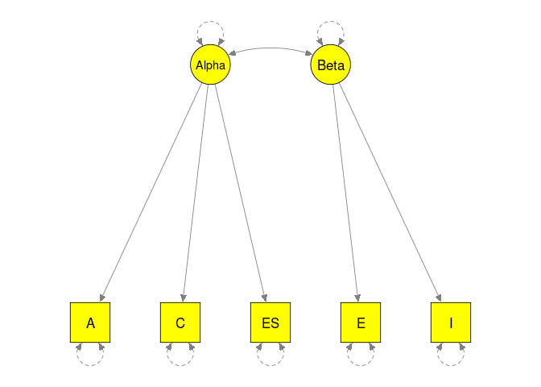

```r
## Display the model
plot(model1, color="yellow")
```

```r
random2 <- tssem2(random1, RAM=RAM1)
summary(random2)
```

```
##
## Call:
## wls(Cov = pooledS, aCov = aCov, n = tssem1.obj$total.n, RAM = RAM,
##     Amatrix = Amatrix, Smatrix = Smatrix, Fmatrix = Fmatrix,
##     diag.constraints = diag.constraints, cor.analysis = cor.analysis,
##     intervals.type = intervals.type, mx.algebras = mx.algebras,
##     mxModel.Args = mxModel.Args, subset.variables = subset.variables,
##     model.name = model.name, suppressWarnings = suppressWarnings,
##     silent = silent, run = run)
##
## 95% confidence intervals: z statistic approximation
## Coefficients:
##               Estimate Std.Error   lbound   ubound z value  Pr(>|z|)
## AONAlpha      0.569435  0.052425 0.466684 0.672187 10.8619 < 2.2e-16 ***
## CONAlpha      0.590630  0.052649 0.487439 0.693821 11.2182 < 2.2e-16 ***
## EONBeta       0.679955  0.075723 0.531541 0.828370  8.9795 < 2.2e-16 ***
## ESONAlpha     0.760455  0.061963 0.639009 0.881901 12.2726 < 2.2e-16 ***
## IONBeta       0.641842  0.072459 0.499825 0.783859  8.8580 < 2.2e-16 ***
## AlphaWITHBeta 0.377691  0.047402 0.284785 0.470596  7.9679 1.554e-15 ***
## ---
## Signif. codes:  0 '***' 0.001 '**' 0.01 '*' 0.05 '.' 0.1 ' ' 1
##
## Goodness-of-fit indices:
##                                                Value
## Sample size                                4496.0000
## Chi-square of target model                    7.8204
## DF of target model                            4.0000
## p value of target model                       0.0984
## Number of constraints imposed on "Smatrix"    0.0000
## DF manually adjusted                          0.0000
## Chi-square of independence model            501.6768
## DF of independence model                     10.0000
## RMSEA                                         0.0146
## RMSEA lower 95% CI                            0.0000
## RMSEA upper 95% CI                            0.0297
## SRMR                                          0.0436
## TLI                                           0.9806
## CFI                                           0.9922
## AIC                                          -0.1796
## BIC                                         -25.8234
## OpenMx status1: 0 ("0" or "1": The optimization is considered fine.
## Other values indicate problems.)
```

## Model with uncorrelated factors

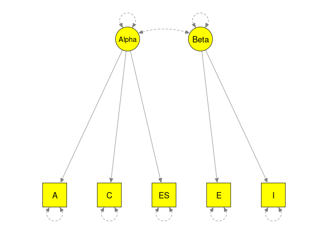

```r
## Model with uncorrelated factors
model2 <- "## Alpha is measured by A, C, and ES
           Alpha =~ A + C + ES
           ## Beta is measured by E and I
           Beta =~ E + I
           ## Factor correlation between Alpha and Beta fixed at 0
           Alpha ~~ 0*Beta"

## Display the model
plot(model2, color="yellow")
```

```r
RAM2 <- lavaan2RAM(model2, obs.variables=c("A","C","ES","E","I"))
RAM2
```

```
## $A
##       A   C   ES  E   I   Alpha           Beta
## A     "0" "0" "0" "0" "0" "0.1*AONAlpha"  "0"
## C     "0" "0" "0" "0" "0" "0.1*CONAlpha"  "0"
## ES    "0" "0" "0" "0" "0" "0.1*ESONAlpha" "0"
## E     "0" "0" "0" "0" "0" "0"             "0.1*EONBeta"
## I     "0" "0" "0" "0" "0" "0"             "0.1*IONBeta"
## Alpha "0" "0" "0" "0" "0" "0"             "0"
## Beta  "0" "0" "0" "0" "0" "0"             "0"
##
## $S
##       A            C            ES             E            I            Alpha
## A     "0.5*AWITHA" "0"          "0"            "0"          "0"          "0"
## C     "0"          "0.5*CWITHC" "0"            "0"          "0"          "0"
## ES    "0"          "0"          "0.5*ESWITHES" "0"          "0"          "0"
## E     "0"          "0"          "0"            "0.5*EWITHE" "0"          "0"
## I     "0"          "0"          "0"            "0"          "0.5*IWITHI" "0"
## Alpha "0"          "0"          "0"            "0"          "0"          "1"
## Beta  "0"          "0"          "0"            "0"          "0"          "0"
##       Beta
## A     "0"
## C     "0"
## ES    "0"
## E     "0"
## I     "0"
## Alpha "0"
## Beta  "1"
##
## $F
##    A C ES E I Alpha Beta
## A  1 0  0 0 0     0    0
## C  0 1  0 0 0     0    0
## ES 0 0  1 0 0     0    0
## E  0 0  0 1 0     0    0
## I  0 0  0 0 1     0    0
##
## $M
##   A C ES E I Alpha Beta
## 1 0 0  0 0 0     0    0
```

```r
random2a <- tssem2(random1, RAM=RAM2)
summary(random2a)
```

```
##
## Call:
## wls(Cov = pooledS, aCov = aCov, n = tssem1.obj$total.n, RAM = RAM,
##     Amatrix = Amatrix, Smatrix = Smatrix, Fmatrix = Fmatrix,
##     diag.constraints = diag.constraints, cor.analysis = cor.analysis,
##     intervals.type = intervals.type, mx.algebras = mx.algebras,
##     mxModel.Args = mxModel.Args, subset.variables = subset.variables,
##     model.name = model.name, suppressWarnings = suppressWarnings,
##     silent = silent, run = run)
##
## 95% confidence intervals: z statistic approximation
## Coefficients:
##           Estimate Std.Error   lbound   ubound z value  Pr(>|z|)
## AONAlpha  0.627034  0.060888 0.507695 0.746373  10.298 < 2.2e-16 ***
## CONAlpha  0.611058  0.059098 0.495228 0.726888  10.340 < 2.2e-16 ***
## EONBeta   0.650593        NA       NA       NA      NA        NA
## ESONAlpha 0.679051  0.065154 0.551351 0.806752  10.422 < 2.2e-16 ***
## IONBeta   0.650593        NA       NA       NA      NA        NA
## ---
## Signif. codes:  0 '***' 0.001 '**' 0.01 '*' 0.05 '.' 0.1 ' ' 1
##
## Goodness-of-fit indices:
##                                                Value
## Sample size                                4496.0000
## Chi-square of target model                   80.6783
## DF of target model                            5.0000
## p value of target model                       0.0000
## Number of constraints imposed on "Smatrix"    0.0000
## DF manually adjusted                          0.0000
## Chi-square of independence model            501.6768
## DF of independence model                     10.0000
## RMSEA                                         0.0580
## RMSEA lower 95% CI                            0.0473
## RMSEA upper 95% CI                            0.0695
## SRMR                                          0.1216
## TLI                                           0.6922
## CFI                                           0.8461
## AIC                                          70.6783
## BIC                                          38.6235
## OpenMx status1: 5 ("0" or "1": The optimization is considered fine.
## Other values indicate problems.)
```

```r
## OpenMx statu1 = 5, we may rerun the analysis to see if we can get better results
random2a <- rerun(random2a)
```

```
## Running TSSEM2 Correlation with 5 parameters
```

```
##
## Beginning initial fit attempt
```

```
## Running TSSEM2 Correlation with 5 parameters
```

```
##
##  Lowest minimum so far:  80.6782518105521
```

```
##
## Solution found
```

```
##
##  Solution found!  Final fit=80.678252 (started at 80.678252)  (1 attempt(s): 1 valid, 0 errors)
```

```r
summary(random2a)
```

```
##
## Call:
## wls(Cov = pooledS, aCov = aCov, n = tssem1.obj$total.n, RAM = RAM,
##     Amatrix = Amatrix, Smatrix = Smatrix, Fmatrix = Fmatrix,
##     diag.constraints = diag.constraints, cor.analysis = cor.analysis,
##     intervals.type = intervals.type, mx.algebras = mx.algebras,
##     mxModel.Args = mxModel.Args, subset.variables = subset.variables,
##     model.name = model.name, suppressWarnings = suppressWarnings,
##     silent = silent, run = run)
##
## 95% confidence intervals: z statistic approximation
## Coefficients:
##             Estimate  Std.Error     lbound     ubound z value Pr(>|z|)
## AONAlpha    0.627034   0.060888   0.507695   0.746373 10.2981   <2e-16 ***
## CONAlpha    0.611058   0.059098   0.495228   0.726888 10.3397   <2e-16 ***
## EONBeta     0.650593  42.472621 -82.594215  83.895401  0.0153   0.9878
## ESONAlpha   0.679051   0.065154   0.551351   0.806752 10.4222   <2e-16 ***
## IONBeta     0.650593  42.472621 -82.594215  83.895401  0.0153   0.9878
## ---
## Signif. codes:  0 '***' 0.001 '**' 0.01 '*' 0.05 '.' 0.1 ' ' 1
##
## Goodness-of-fit indices:
##                                                Value
## Sample size                                4496.0000
## Chi-square of target model                   80.6783
## DF of target model                            5.0000
## p value of target model                       0.0000
## Number of constraints imposed on "Smatrix"    0.0000
## DF manually adjusted                          0.0000
## Chi-square of independence model            501.6768
## DF of independence model                     10.0000
## RMSEA                                         0.0580
## RMSEA lower 95% CI                            0.0473
## RMSEA upper 95% CI                            0.0695
## SRMR                                          0.1216
## TLI                                           0.6922
## CFI                                           0.8461
## AIC                                          70.6783
## BIC                                          38.6235
## OpenMx status1: 0 ("0" or "1": The optimization is considered fine.
## Other values indicate problems.)
```

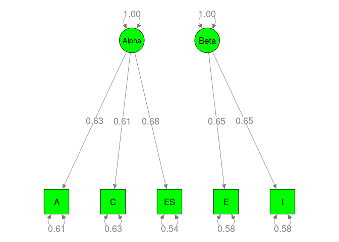

```r
## Plot the parameter estimates
plot(random2a, color="green")
```

```r
## Comparing them with a chi-square statistic
anova(random2, random2a)
```

```
##                 base         comparison ep  minus2LL df      AIC  diffLL diffdf
## 1 TSSEM2 Correlation               <NA>  6  7.820355 -6 19.82035      NA     NA
## 2 TSSEM2 Correlation TSSEM2 Correlation  5 80.678252 -5 90.67825 72.8579      1
##             p
## 1          NA
## 2 1.39329e-17
```

## Further analysis 2

- On the other hand, some researchers propose a general personality among the Big Five.[^1]
- We may verify if Digman’s data support this theory.
- Result shows that $\Delta\chi^2(1)=93.91, p<.0001$. Thus, the general factor model does not fit the data.

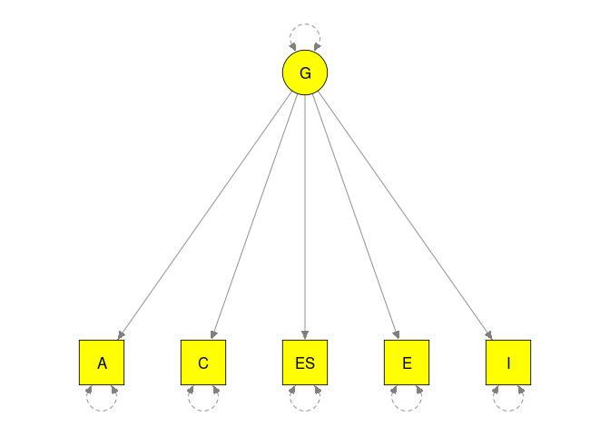

```r
## Model with a general personality factor
model3 <- "## Factor loadings
           G =~ A + C + ES + E + I"

## Display the model
plot(model3, color="yellow")
```

```r
RAM3 <- lavaan2RAM(model3, obs.variables=c("A","C","ES","E","I"),
                   A.notation = "on", S.notation = "with")
RAM3
```

```
## $A
##    A   C   ES  E   I   G
## A  "0" "0" "0" "0" "0" "0.1*AonG"
## C  "0" "0" "0" "0" "0" "0.1*ConG"
## ES "0" "0" "0" "0" "0" "0.1*ESonG"
## E  "0" "0" "0" "0" "0" "0.1*EonG"
## I  "0" "0" "0" "0" "0" "0.1*IonG"
## G  "0" "0" "0" "0" "0" "0"
##
## $S
##    A            C            ES             E            I            G
## A  "0.5*AwithA" "0"          "0"            "0"          "0"          "0"
## C  "0"          "0.5*CwithC" "0"            "0"          "0"          "0"
## ES "0"          "0"          "0.5*ESwithES" "0"          "0"          "0"
## E  "0"          "0"          "0"            "0.5*EwithE" "0"          "0"
## I  "0"          "0"          "0"            "0"          "0.5*IwithI" "0"
## G  "0"          "0"          "0"            "0"          "0"          "1"
##
## $F
##    A C ES E I G
## A  1 0  0 0 0 0
## C  0 1  0 0 0 0
## ES 0 0  1 0 0 0
## E  0 0  0 1 0 0
## I  0 0  0 0 1 0
##
## $M
##   A C ES E I G
## 1 0 0  0 0 0 0
```

```r
random2b <- tssem2(random1, RAM=RAM3)
summary(random2b)
```

```
##
## Call:
## wls(Cov = pooledS, aCov = aCov, n = tssem1.obj$total.n, RAM = RAM,
##     Amatrix = Amatrix, Smatrix = Smatrix, Fmatrix = Fmatrix,
##     diag.constraints = diag.constraints, cor.analysis = cor.analysis,
##     intervals.type = intervals.type, mx.algebras = mx.algebras,
##     mxModel.Args = mxModel.Args, subset.variables = subset.variables,
##     model.name = model.name, suppressWarnings = suppressWarnings,
##     silent = silent, run = run)
##
## 95% confidence intervals: z statistic approximation
## Coefficients:
##       Estimate Std.Error   lbound   ubound z value  Pr(>|z|)
## AonG  0.513737  0.047999 0.419662 0.607813  10.703 < 2.2e-16 ***
## ConG  0.551676  0.044962 0.463552 0.639800  12.270 < 2.2e-16 ***
## EonG  0.478533  0.040395 0.399360 0.557706  11.846 < 2.2e-16 ***
## ESonG 0.637111  0.044654 0.549590 0.724631  14.268 < 2.2e-16 ***
## IonG  0.502138  0.045018 0.413904 0.590371  11.154 < 2.2e-16 ***
## ---
## Signif. codes:  0 '***' 0.001 '**' 0.01 '*' 0.05 '.' 0.1 ' ' 1
##
## Goodness-of-fit indices:
##                                                Value
## Sample size                                4496.0000
## Chi-square of target model                  101.7275
## DF of target model                            5.0000
## p value of target model                       0.0000
## Number of constraints imposed on "Smatrix"    0.0000
## DF manually adjusted                          0.0000
## Chi-square of independence model            501.6768
## DF of independence model                     10.0000
## RMSEA                                         0.0656
## RMSEA lower 95% CI                            0.0548
## RMSEA upper 95% CI                            0.0770
## SRMR                                          0.1359
## TLI                                           0.6065
## CFI                                           0.8033
## AIC                                          91.7275
## BIC                                          59.6727
## OpenMx status1: 0 ("0" or "1": The optimization is considered fine.
## Other values indicate problems.)
```

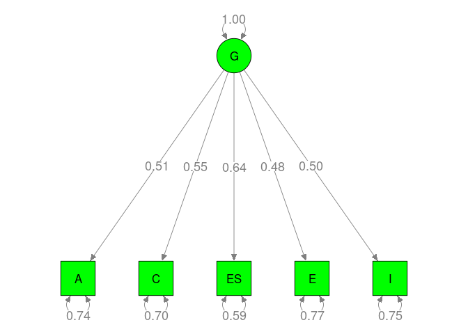

```r
## Plot the parameter estimates
plot(random2b, color="green")
```

```r
## Comparing them with a chi-square statistic
anova(random2, random2b)
```

```
##                 base         comparison ep   minus2LL df       AIC  diffLL
## 1 TSSEM2 Correlation               <NA>  6   7.820355 -6  19.82035      NA
## 2 TSSEM2 Correlation TSSEM2 Correlation  5 101.727459 -5 111.72746 93.9071
##   diffdf            p
## 1     NA           NA
## 2      1 3.306851e-22
```

## Further analysis 3

- It is interesting to test if the factor loadings are the same in each factor.
- This can be easily done using the same labels in the model specification.
- Since these two models are nested, we may compare them with a chi-square difference statistic. The result shows that the change is not statistically significant, $\Delta\chi^2(3)=4.62, p=.20$, which indicates that the factor loadings are the same in each factor.

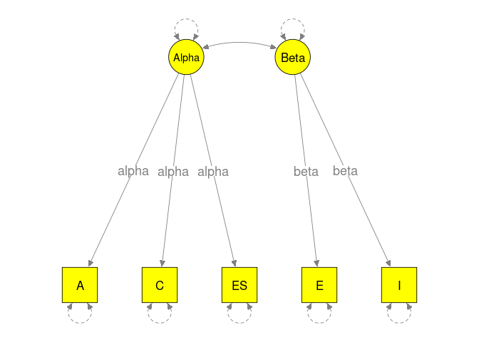

```r
## Model with the same factor loadings within the factor
model4 <- "## Factor loadings
           ## Alpha is measured by A, C, and ES
           Alpha =~ alpha*A + alpha*C + alpha*ES
           ## Beta is measured by E and I
           Beta =~ beta*E + beta*I
           ## Factor correlation between Alpha and Beta
           Alpha ~~ Beta"

## Display the model
plot(model4, color="yellow")
```

```r
RAM4 <- lavaan2RAM(model4, obs.variables=c("A","C","ES","E","I"))
RAM4
```

```
## $A
##       A   C   ES  E   I   Alpha       Beta
## A     "0" "0" "0" "0" "0" "0.1*alpha" "0"
## C     "0" "0" "0" "0" "0" "0.1*alpha" "0"
## ES    "0" "0" "0" "0" "0" "0.1*alpha" "0"
## E     "0" "0" "0" "0" "0" "0"         "0.1*beta"
## I     "0" "0" "0" "0" "0" "0"         "0.1*beta"
## Alpha "0" "0" "0" "0" "0" "0"         "0"
## Beta  "0" "0" "0" "0" "0" "0"         "0"
##
## $S
##       A            C            ES             E            I
## A     "0.5*AWITHA" "0"          "0"            "0"          "0"
## C     "0"          "0.5*CWITHC" "0"            "0"          "0"
## ES    "0"          "0"          "0.5*ESWITHES" "0"          "0"
## E     "0"          "0"          "0"            "0.5*EWITHE" "0"
## I     "0"          "0"          "0"            "0"          "0.5*IWITHI"
## Alpha "0"          "0"          "0"            "0"          "0"
## Beta  "0"          "0"          "0"            "0"          "0"
##       Alpha             Beta
## A     "0"               "0"
## C     "0"               "0"
## ES    "0"               "0"
## E     "0"               "0"
## I     "0"               "0"
## Alpha "1"               "0*AlphaWITHBeta"
## Beta  "0*AlphaWITHBeta" "1"
##
## $F
##    A C ES E I Alpha Beta
## A  1 0  0 0 0     0    0
## C  0 1  0 0 0     0    0
## ES 0 0  1 0 0     0    0
## E  0 0  0 1 0     0    0
## I  0 0  0 0 1     0    0
##
## $M
##   A C ES E I Alpha Beta
## 1 0 0  0 0 0     0    0
```

```r
random2c <- tssem2(random1, RAM=RAM4)
summary(random2c)
```

```
##
## Call:
## wls(Cov = pooledS, aCov = aCov, n = tssem1.obj$total.n, RAM = RAM,
##     Amatrix = Amatrix, Smatrix = Smatrix, Fmatrix = Fmatrix,
##     diag.constraints = diag.constraints, cor.analysis = cor.analysis,
##     intervals.type = intervals.type, mx.algebras = mx.algebras,
##     mxModel.Args = mxModel.Args, subset.variables = subset.variables,
##     model.name = model.name, suppressWarnings = suppressWarnings,
##     silent = silent, run = run)
##
## 95% confidence intervals: z statistic approximation
## Coefficients:
##               Estimate Std.Error   lbound   ubound z value  Pr(>|z|)
## alpha         0.650584  0.020199 0.610995 0.690174 32.2086 < 2.2e-16 ***
## beta          0.660172  0.024271 0.612602 0.707743 27.1997 < 2.2e-16 ***
## AlphaWITHBeta 0.377146  0.047851 0.283360 0.470932  7.8817 3.331e-15 ***
## ---
## Signif. codes:  0 '***' 0.001 '**' 0.01 '*' 0.05 '.' 0.1 ' ' 1
##
## Goodness-of-fit indices:
##                                                Value
## Sample size                                4496.0000
## Chi-square of target model                   12.4431
## DF of target model                            7.0000
## p value of target model                       0.0869
## Number of constraints imposed on "Smatrix"    0.0000
## DF manually adjusted                          0.0000
## Chi-square of independence model            501.6768
## DF of independence model                     10.0000
## RMSEA                                         0.0132
## RMSEA lower 95% CI                            0.0000
## RMSEA upper 95% CI                            0.0248
## SRMR                                          0.0506
## TLI                                           0.9842
## CFI                                           0.9889
## AIC                                          -1.5569
## BIC                                         -46.4335
## OpenMx status1: 0 ("0" or "1": The optimization is considered fine.
## Other values indicate problems.)
```

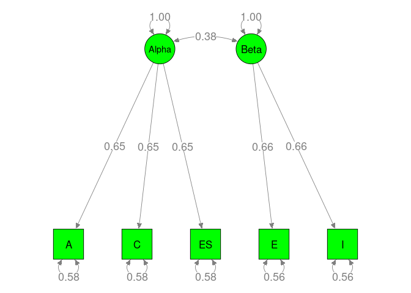

```r
## Plot the parameter estimates
plot(random2c, color="green")
```

```r
## Comparing them with a chi-square statistic
anova(random2, random2c)
```

```
##                 base         comparison ep  minus2LL df      AIC   diffLL
## 1 TSSEM2 Correlation               <NA>  6  7.820355 -6 19.82035       NA
## 2 TSSEM2 Correlation TSSEM2 Correlation  3 12.443132 -3 18.44313 4.622777
##   diffdf         p
## 1     NA        NA
## 2      3 0.2015968
```

## Example 2: A path model

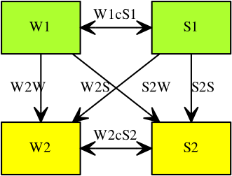

### Data preparation

- The dataset is available as [`NoheA1`](https://www.rdocumentation.org/packages/metaSEM/versions/1.3.0/topics/Nohe15) in the metaSEM package. To illustrate how to read it as an external file, we have exported it as an Excel file Nohe15.xlsx.

```r
library(readxl)
library(metaSEM)

## Read the Excel file
df <- read_xlsx("Nohe15.xlsx", sheet="Table A1")

head(df)
```

```
## # A tibble: 6 × 18
##   Study         N Parti…¹ Country Strain RelW1 RelW2 RelS1 RelS2 % Wom…² Publi…³
##   <chr>     <dbl> <chr>   <chr>   <chr>  <dbl> <dbl> <dbl> <dbl>   <dbl> <chr>
## 1 Britt & …   489 Soldie… United… Depre…  0.94  0.94  0.8   0.8       15 P
## 2 Demerout…   335 Employ… the Ne… Exhau…  0.79  0.81  0.85  0.89      70 P
## 3 Ford (20…   328 Hetero… United… Depre…  0.8   0.81  0.82  0.84      49 U
## 4 Hammer e…   234 Wives … United… Depre…  0.91  0.91  0.9   0.9      100 P
## 5 Hammer e…   234 Husban… United… Depre…  0.9   0.9   0.87  0.87       0 P
## 6 Innstran…  2235 Profes… Norway  Exhau…  0.7   0.7   0.86  0.88      46 P
## # … with 7 more variables: Lag <dbl>, `W1-S2` <dbl>, `S1-W2` <dbl>,
## #   `W1-S1` <dbl>, `W2-S2` <dbl>, `W1-W2` <dbl>, `S1-S2` <dbl>, and abbreviated
## #   variable names ¹Participants, ²`% Women`, ³`Publication Status`
```

```r
## Variable names
my.var <- c("W1", "S1", "W2", "S2")

## Split each row as a list
my.list <- split(df, 1:nrow(df))


## Select the correlation coefficients and convert it into a correlation matrix
my.cor <- lapply(my.list,
                 function(x) {## Convert the correlations into a correlation matrix
                              mat <- vec2symMat(unlist(x[c("W1-S1","W1-W2","W1-S2","S1-W2","S1-S2","W2-S2")]), diag = FALSE)
                              ## Add the dimensions for ease of reference
                              dimnames(mat) <- list(my.var, my.var)
                              ## Return the correlation matrix
                              mat})

## Add the study names for ease of reference
names(my.cor) <- df$Study

head(my.cor)
```

```
## $`Britt & Dawson (2005)`
##      W1   S1   W2   S2
## W1 1.00 0.29 0.58 0.22
## S1 0.29 1.00 0.24 0.57
## W2 0.58 0.24 1.00 0.27
## S2 0.22 0.57 0.27 1.00
##
## $`Demerouti et al. (2004)`
##      W1   S1   W2   S2
## W1 1.00 0.53 0.57 0.41
## S1 0.53 1.00 0.41 0.68
## W2 0.57 0.41 1.00 0.54
## S2 0.41 0.68 0.54 1.00
##
## $`Ford (2010)`
##      W1   S1   W2   S2
## W1 1.00 0.35 0.75 0.32
## S1 0.35 1.00 0.26 0.74
## W2 0.75 0.26 1.00 0.30
## S2 0.32 0.74 0.30 1.00
##
## $`Hammer et al. (2005), female subsample`
##      W1   S1   W2   S2
## W1 1.00 0.32 0.57 0.22
## S1 0.32 1.00 0.30 0.43
## W2 0.57 0.30 1.00 0.30
## S2 0.22 0.43 0.30 1.00
##
## $`Hammer et al. (2005), male subsample`
##      W1   S1   W2   S2
## W1 1.00 0.19 0.54 0.17
## S1 0.19 1.00 0.21 0.60
## W2 0.54 0.21 1.00 0.30
## S2 0.17 0.60 0.30 1.00
##
## $`Innstrand et al. (2008)`
##      W1   S1   W2   S2
## W1 1.00 0.42 0.63 0.31
## S1 0.42 1.00 0.30 0.62
## W2 0.63 0.30 1.00 0.44
## S2 0.31 0.62 0.44 1.00
```

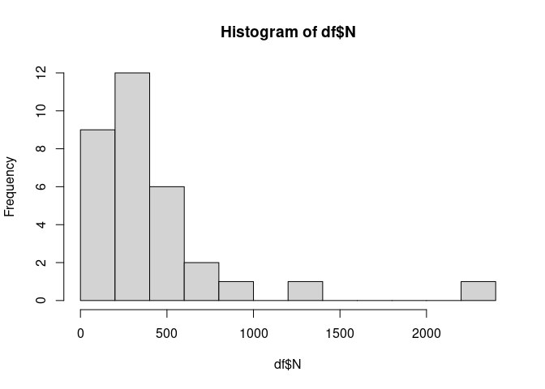

```r
## Sample sizes
hist(df$N, breaks=10)
```

```r
## Display the no. of studies
pattern.na(my.cor, show.na=FALSE)
```

```
##    W1 S1 W2 S2
## W1 32 32 32 32
## S1 32 32 32 32
## W2 32 32 32 32
## S2 32 32 32 32
```

```r
## Display the cumulative sample sizes
pattern.n(my.cor, df$N)
```

```
##       W1    S1    W2    S2
## W1 12906 12906 12906 12906
## S1 12906 12906 12906 12906
## W2 12906 12906 12906 12906
## S2 12906 12906 12906 12906
```

## TSSEM Stage 1 analysis: Fixed-effects model

- We use both a fixed-effects and random-effects model to meta-analyze the correlation matrices. Since the fixed-effects model does not fit the data, we will focus on the random-effects model.
- The interpretations are similar to those in a multivariate meta-analysis.
  - The likelihood ratio (LR) statistic in testing the homogeneity of correlation matrices is $\chi^2(df=186)=1,524, p < .001$, suggesting that the fixed-effects model does not fit the data well.

```r
## Fit the stage one model (fixed-effects model)
fix1 <- tssem1(my.cor, df$N, method="FEM")
summary(fix1)
```

```
##
## Call:
## tssem1FEM(Cov = Cov, n = n, cor.analysis = cor.analysis, model.name = model.name,
##     cluster = cluster, suppressWarnings = suppressWarnings, silent = silent,
##     run = run)
##
## Coefficients:
##         Estimate Std.Error z value  Pr(>|z|)
## S[1,2] 0.4239505 0.0073296  57.841 < 2.2e-16 ***
## S[1,3] 0.6242536 0.0054291 114.983 < 2.2e-16 ***
## S[1,4] 0.3349734 0.0078889  42.462 < 2.2e-16 ***
## S[2,3] 0.3288615 0.0079184  41.532 < 2.2e-16 ***
## S[2,4] 0.6315353 0.0053669 117.672 < 2.2e-16 ***
## S[3,4] 0.4342405 0.0072613  59.802 < 2.2e-16 ***
## ---
## Signif. codes:  0 '***' 0.001 '**' 0.01 '*' 0.05 '.' 0.1 ' ' 1
##
## Goodness-of-fit indices:
##                                       Value
## Sample size                      12906.0000
## Chi-square of target model        1524.9269
## DF of target model                 186.0000
## p value of target model              0.0000
## Chi-square of independence model 18047.6811
## DF of independence model           192.0000
## RMSEA                                0.1336
## RMSEA lower 95% CI                   0.1276
## RMSEA upper 95% CI                   0.1400
## SRMR                                 0.1096
## TLI                                  0.9226
## CFI                                  0.9250
## AIC                               1152.9269
## BIC                               -235.6464
## OpenMx status1: 0 ("0" or "1": The optimization is considered fine.
## Other values may indicate problems.)
```

## TSSEM Stage 1 analysis: Random-effects model

```r
## Fit the stage one model (random-effects model)
rand1 <- tssem1(my.cor, df$N, method="REM")
summary(rand1)
```

```
##
## Call:
## meta(y = ES, v = acovR, RE.constraints = Diag(paste0(RE.startvalues,
##     "*Tau2_", 1:no.es, "_", 1:no.es)), RE.lbound = RE.lbound,
##     I2 = I2, model.name = model.name, suppressWarnings = TRUE,
##     silent = silent, run = run)
##
## 95% confidence intervals: z statistic approximation (robust=FALSE)
## Coefficients:
##             Estimate Std.Error    lbound    ubound z value  Pr(>|z|)
## Intercept1 0.3804522 0.0225616 0.3362323 0.4246720 16.8628 < 2.2e-16 ***
## Intercept2 0.6051298 0.0180362 0.5697794 0.6404802 33.5508 < 2.2e-16 ***
## Intercept3 0.3032290 0.0178803 0.2681842 0.3382738 16.9588 < 2.2e-16 ***
## Intercept4 0.3036392 0.0178408 0.2686718 0.3386065 17.0194 < 2.2e-16 ***
## Intercept5 0.6166503 0.0166427 0.5840312 0.6492694 37.0523 < 2.2e-16 ***
## Intercept6 0.3954085 0.0216645 0.3529469 0.4378701 18.2515 < 2.2e-16 ***
## Tau2_1_1   0.0134777 0.0038704 0.0058919 0.0210635  3.4823 0.0004972 ***
## Tau2_2_2   0.0087592 0.0025260 0.0038083 0.0137102  3.4676 0.0005252 ***
## Tau2_3_3   0.0071123 0.0022470 0.0027082 0.0115163  3.1652 0.0015496 **
## Tau2_4_4   0.0070585 0.0022121 0.0027229 0.0113941  3.1909 0.0014183 **
## Tau2_5_5   0.0072634 0.0021092 0.0031293 0.0113974  3.4436 0.0005740 ***
## Tau2_6_6   0.0122813 0.0034848 0.0054513 0.0191114  3.5243 0.0004246 ***
## ---
## Signif. codes:  0 '***' 0.001 '**' 0.01 '*' 0.05 '.' 0.1 ' ' 1
##
## Q statistic on the homogeneity of effect sizes: 1466.163
## Degrees of freedom of the Q statistic: 186
## P value of the Q statistic: 0
##
## Heterogeneity indices (based on the estimated Tau2):
##                              Estimate
## Intercept1: I2 (Q statistic)   0.8829
## Intercept2: I2 (Q statistic)   0.8973
## Intercept3: I2 (Q statistic)   0.7743
## Intercept4: I2 (Q statistic)   0.7718
## Intercept5: I2 (Q statistic)   0.8810
## Intercept6: I2 (Q statistic)   0.8748
##
## Number of studies (or clusters): 32
## Number of observed statistics: 192
## Number of estimated parameters: 12
## Degrees of freedom: 180
## -2 log likelihood: -300.1701
## OpenMx status1: 0 ("0" or "1": The optimization is considered fine.
## Other values may indicate problems.)
```

```r
## Extract the fixed-effects estimates
R1 <- coef(rand1, select = "fixed")
R1
```

```
## Intercept1 Intercept2 Intercept3 Intercept4 Intercept5 Intercept6
##  0.3804522  0.6051298  0.3032290  0.3036392  0.6166503  0.3954085
```

```r
## Convert it to a correlation matrix
R1 <- vec2symMat(R1, diag = FALSE)
R1
```

```
##           [,1]      [,2]      [,3]      [,4]
## [1,] 1.0000000 0.3804522 0.6051298 0.3032290
## [2,] 0.3804522 1.0000000 0.3036392 0.6166503
## [3,] 0.6051298 0.3036392 1.0000000 0.3954085
## [4,] 0.3032290 0.6166503 0.3954085 1.0000000
```

```r
## Add the dimension names for ease of reference
dimnames(R1) <- list(my.var, my.var)
R1
```

```
##           W1        S1        W2        S2
## W1 1.0000000 0.3804522 0.6051298 0.3032290
## S1 0.3804522 1.0000000 0.3036392 0.6166503
## W2 0.6051298 0.3036392 1.0000000 0.3954085
## S2 0.3032290 0.6166503 0.3954085 1.0000000
```

```r
## Heterogeneity: variance-covariance component of the random effects
VarCorr(rand1)
```

```
##            [,1]        [,2]        [,3]        [,4]        [,5]       [,6]
## [1,] 0.01347772 0.000000000 0.000000000 0.000000000 0.000000000 0.00000000
## [2,] 0.00000000 0.008759248 0.000000000 0.000000000 0.000000000 0.00000000
## [3,] 0.00000000 0.000000000 0.007112293 0.000000000 0.000000000 0.00000000
## [4,] 0.00000000 0.000000000 0.000000000 0.007058496 0.000000000 0.00000000
## [5,] 0.00000000 0.000000000 0.000000000 0.000000000 0.007263354 0.00000000
## [6,] 0.00000000 0.000000000 0.000000000 0.000000000 0.000000000 0.01228132
```

### Stage 2 analysis

- We then test the cross-lagged model.
- As the proposed model fits the data perfectly, we ignore the fit indices in the output.

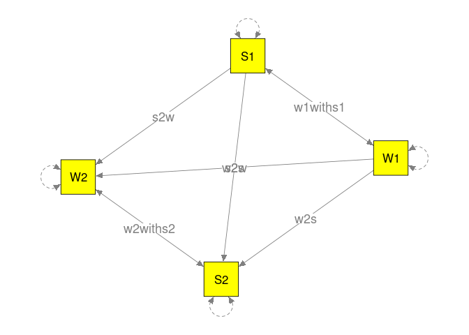

```r
## Model in lavaan syntax
## The parameter labels are not necessary. But they make the output easier to follow.
model1 <- "W2 ~ w2w*W1 + s2w*S1    # path coefficients
           S2 ~ s2s*S1 + w2s*W1
           S1 ~~ w1withs1*W1       # correlation
           S2 ~~ w2withs2*W2
           W1 ~~ 1*W1              # variances of the independent variables are fixed at 1
           S1 ~~ 1*S1"

## Display the model
## See the layout argument in ?semPaths
## layout can be either tree, circle, spring, tree2, or circle2
plot(model1, color="yellow", layout="spring")
```

```r
## Convert the above model to the RAM specification used by metaSEM.
## We also have to specify how the variables are arranged in the data.
RAM1 <- lavaan2RAM(model1, obs.variables = my.var)
RAM1
```

```
## $A
##    W1        S1        W2  S2
## W1 "0"       "0"       "0" "0"
## S1 "0"       "0"       "0" "0"
## W2 "0.1*w2w" "0.1*s2w" "0" "0"
## S2 "0.1*w2s" "0.1*s2s" "0" "0"
##
## $S
##    W1           S1           W2             S2
## W1 "1"          "0*w1withs1" "0"            "0"
## S1 "0*w1withs1" "1"          "0"            "0"
## W2 "0"          "0"          "0.5*W2WITHW2" "0*w2withs2"
## S2 "0"          "0"          "0*w2withs2"   "0.5*S2WITHS2"
##
## $F
##    W1 S1 W2 S2
## W1  1  0  0  0
## S1  0  1  0  0
## W2  0  0  1  0
## S2  0  0  0  1
##
## $M
##   W1 S1 W2 S2
## 1  0  0  0  0
```

```r
## Fit the stage two model
rand2a <- tssem2(rand1, RAM=RAM1)
summary(rand2a)
```

```
##
## Call:
## wls(Cov = pooledS, aCov = aCov, n = tssem1.obj$total.n, RAM = RAM,
##     Amatrix = Amatrix, Smatrix = Smatrix, Fmatrix = Fmatrix,
##     diag.constraints = diag.constraints, cor.analysis = cor.analysis,
##     intervals.type = intervals.type, mx.algebras = mx.algebras,
##     mxModel.Args = mxModel.Args, subset.variables = subset.variables,
##     model.name = model.name, suppressWarnings = suppressWarnings,
##     silent = silent, run = run)
##
## 95% confidence intervals: z statistic approximation
## Coefficients:
##          Estimate Std.Error   lbound   ubound z value  Pr(>|z|)
## s2s      0.586124  0.020790 0.545376 0.626872 28.1926 < 2.2e-16 ***
## w2s      0.080237  0.024842 0.031547 0.128927  3.2299 0.0012385 **
## s2w      0.085841  0.024796 0.037242 0.134440  3.4619 0.0005364 ***
## w2w      0.572471  0.022265 0.528834 0.616109 25.7122 < 2.2e-16 ***
## w1withs1 0.380452  0.022562 0.336232 0.424672 16.8628 < 2.2e-16 ***
## w2withs2 0.168885  0.025232 0.119431 0.218338  6.6933 2.182e-11 ***
## ---
## Signif. codes:  0 '***' 0.001 '**' 0.01 '*' 0.05 '.' 0.1 ' ' 1
##
## Goodness-of-fit indices:
##                                            Value
## Sample size                                12906
## Chi-square of target model                     0
## DF of target model                             0
## p value of target model                        0
## Number of constraints imposed on "Smatrix"     0
## DF manually adjusted                           0
## Chi-square of independence model            3079
## DF of independence model                       6
## RMSEA                                          0
## RMSEA lower 95% CI                             0
## RMSEA upper 95% CI                             0
## SRMR                                           0
## TLI                                         -Inf
## CFI                                            1
## AIC                                            0
## BIC                                            0
## OpenMx status1: 0 ("0" or "1": The optimization is considered fine.
## Other values indicate problems.)
```

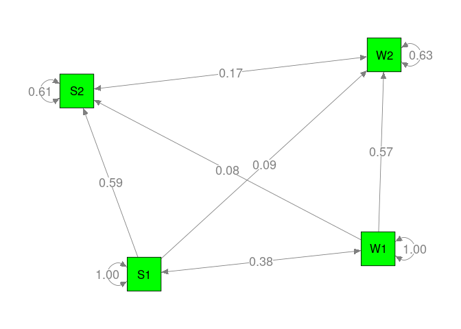

```r
plot(rand2a, color="green", layout="spring")
```

### Further analysis 1: Model with constraints

- Suppose we want to test whether the effects of the same variable pair (`s2s` and `w2w`) are the same and whether the effect of the different variable pair (`s2w` and `w2s`) are the same. We may test them by imposing equality constraints.
- As these two models are nested, we may use a chi-square difference test, also known as a likelihood ratio test, to compare them. The test statistic is $\chi^2(df=2)=0.22, p=.89$, suggesting that there is not enough evidence to reject the null hypothesis that the same pair and different pair effects.

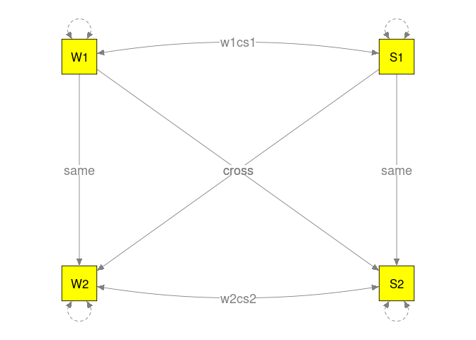

```r
model2 <- "W2 ~ same*W1 + cross*S1     # regression coefficients
           S2 ~ same*S1 + cross*W1
           S1 ~~ w1cs1*W1             # correlation
           S2 ~~ w2cs2*W2
           W1 ~~ 1*W1                 # variances of the independent variables are fixed at 1
           S1 ~~ 1*S1"

## Display the model
plot(model2, color="yellow")
```

```r
## Convert the above model to the RAM specification used by metaSEM.
## We also have to specify how the variables are arranged in the data.
RAM2 <- lavaan2RAM(model2, obs.variables = my.var)
RAM2
```

```
## $A
##    W1          S1          W2  S2
## W1 "0"         "0"         "0" "0"
## S1 "0"         "0"         "0" "0"
## W2 "0.1*same"  "0.1*cross" "0" "0"
## S2 "0.1*cross" "0.1*same"  "0" "0"
##
## $S
##    W1        S1        W2             S2
## W1 "1"       "0*w1cs1" "0"            "0"
## S1 "0*w1cs1" "1"       "0"            "0"
## W2 "0"       "0"       "0.5*W2WITHW2" "0*w2cs2"
## S2 "0"       "0"       "0*w2cs2"      "0.5*S2WITHS2"
##
## $F
##    W1 S1 W2 S2
## W1  1  0  0  0
## S1  0  1  0  0
## W2  0  0  1  0
## S2  0  0  0  1
##
## $M
##   W1 S1 W2 S2
## 1  0  0  0  0
```

```r
## Fit the stage two model
rand2b <- tssem2(rand1, RAM=RAM2)
summary(rand2b)
```

```
##
## Call:
## wls(Cov = pooledS, aCov = aCov, n = tssem1.obj$total.n, RAM = RAM,
##     Amatrix = Amatrix, Smatrix = Smatrix, Fmatrix = Fmatrix,
##     diag.constraints = diag.constraints, cor.analysis = cor.analysis,
##     intervals.type = intervals.type, mx.algebras = mx.algebras,
##     mxModel.Args = mxModel.Args, subset.variables = subset.variables,
##     model.name = model.name, suppressWarnings = suppressWarnings,
##     silent = silent, run = run)
##
## 95% confidence intervals: z statistic approximation
## Coefficients:
##       Estimate Std.Error   lbound   ubound z value  Pr(>|z|)
## cross 0.082840  0.019712 0.044206 0.121474  4.2026 2.638e-05 ***
## same  0.579844  0.015217 0.550020 0.609669 38.1053 < 2.2e-16 ***
## w1cs1 0.380451  0.022562 0.336231 0.424671 16.8628 < 2.2e-16 ***
## w2cs2 0.168824  0.025241 0.119353 0.218295  6.6886 2.254e-11 ***
## ---
## Signif. codes:  0 '***' 0.001 '**' 0.01 '*' 0.05 '.' 0.1 ' ' 1
##
## Goodness-of-fit indices:
##                                                 Value
## Sample size                                12906.0000
## Chi-square of target model                     0.2247
## DF of target model                             2.0000
## p value of target model                        0.8937
## Number of constraints imposed on "Smatrix"     0.0000
## DF manually adjusted                           0.0000
## Chi-square of independence model            3078.9540
## DF of independence model                       6.0000
## RMSEA                                          0.0000
## RMSEA lower 95% CI                             0.0000
## RMSEA upper 95% CI                             0.0079
## SRMR                                           0.0033
## TLI                                            1.0017
## CFI                                            1.0000
## AIC                                           -3.7753
## BIC                                          -18.7062
## OpenMx status1: 0 ("0" or "1": The optimization is considered fine.
## Other values indicate problems.)
```

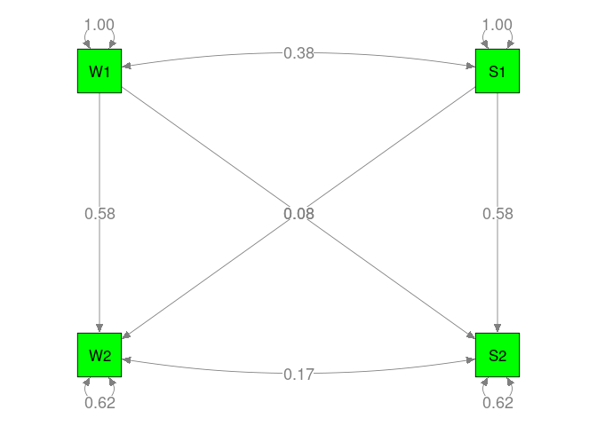

```r
plot(rand2b, color="green")
```

```r
## Comparing nested models with anova()
anova(rand2a, rand2b)
```

```
##                 base         comparison ep     minus2LL df       AIC    diffLL
## 1 TSSEM2 Correlation               <NA>  6 1.245602e-19 -6 12.000000        NA
## 2 TSSEM2 Correlation TSSEM2 Correlation  4 2.246694e-01 -4  8.224669 0.2246694
##   diffdf         p
## 1     NA        NA
## 2      2 0.8937451
```

### Further analysis 2: R² of the dependent variables

- Researchers want to report the explained variance (R²), which indicates the percentage of variances explained by the predictors.
- The definition is $R^2=\frac{SS_\mathrm{explained}}{SS_\mathrm{total}} = 1- \frac{SS_\mathrm{unexplained}}{SS_\mathrm{total}}$, where $SS$ is the sum of squares. It equals $R^2= 1 - \mathrm{Var}(e)$ in correlation analysis.
- However, we do not have the error variances in our outputs because the error variances are not parameters in the correlation analysis.
- We may get the error variances by using the `diag.constraints=TRUE` argument, which forces the program to include the error variances in the models. Nonlinear constraints are applied to ensure that the diagonals are 1.
- We may use the parameter labels to define the R2 using the `:=` syntax.
- The estimated R²s are .37 and .39 for `W2` and `S2`, respectively.

```r
model3 <- "W2 ~ w2w*W1 + s2w*S1    # path coefficients
           S2 ~ s2s*S1 + w2s*W1
           S1 ~~ w1withs1*W1       # correlation
           S2 ~~ w2withs2*W2
           W1 ~~ 1*W1              # variances of the independent variables are fixed at 1
           S1 ~~ 1*S1
           W2 ~~ VarW2*W2          # Label the error variances VarW2 and VarS2
           S2 ~~ VarS2*S2
           R2_W2 := 1 - VarW2      # Define R2 for W2
           R2_S2 := 1 - VarS2      # Define R2 for S2
"

RAM3 <- lavaan2RAM(model3, obs.variables = my.var)
RAM3
```

```
## $A
##    W1        S1        W2  S2
## W1 "0"       "0"       "0" "0"
## S1 "0"       "0"       "0" "0"
## W2 "0.1*w2w" "0.1*s2w" "0" "0"
## S2 "0.1*w2s" "0.1*s2s" "0" "0"
##
## $S
##    W1           S1           W2           S2
## W1 "1"          "0*w1withs1" "0"          "0"
## S1 "0*w1withs1" "1"          "0"          "0"
## W2 "0"          "0"          "0.5*VarW2"  "0*w2withs2"
## S2 "0"          "0"          "0*w2withs2" "0.5*VarS2"
##
## $F
##    W1 S1 W2 S2
## W1  1  0  0  0
## S1  0  1  0  0
## W2  0  0  1  0
## S2  0  0  0  1
##
## $M
##   W1 S1 W2 S2
## 1  0  0  0  0
##
## $mxalgebras
## $mxalgebras$R2_W2
## mxAlgebra 'R2_W2'
## $formula:  1 - VarW2
## $result: (not yet computed) <0 x 0 matrix>
## dimnames: NULL
##
## $mxalgebras$R2_S2
## mxAlgebra 'R2_S2'
## $formula:  1 - VarS2
## $result: (not yet computed) <0 x 0 matrix>
## dimnames: NULL
```

```r
## Fit the stage two model
## diag.constraints=TRUE to involve the error variances in the model
rand2c <- tssem2(rand1, RAM=RAM3, diag.constraints=TRUE)
summary(rand2c)
```

```
##
## Call:
## wls(Cov = pooledS, aCov = aCov, n = tssem1.obj$total.n, RAM = RAM,
##     Amatrix = Amatrix, Smatrix = Smatrix, Fmatrix = Fmatrix,
##     diag.constraints = diag.constraints, cor.analysis = cor.analysis,
##     intervals.type = intervals.type, mx.algebras = mx.algebras,
##     mxModel.Args = mxModel.Args, subset.variables = subset.variables,
##     model.name = model.name, suppressWarnings = suppressWarnings,
##     silent = silent, run = run)
##
## 95% confidence intervals: z statistic approximation
## Coefficients:
##          Estimate Std.Error   lbound   ubound z value  Pr(>|z|)
## s2s      0.586124  0.020790 0.545376 0.626872 28.1926 < 2.2e-16 ***
## w2s      0.080237  0.024842 0.031547 0.128927  3.2299 0.0012385 **
## s2w      0.085841  0.024796 0.037242 0.134440  3.4619 0.0005364 ***
## w2w      0.572471  0.022265 0.528834 0.616109 25.7122 < 2.2e-16 ***
## w1withs1 0.380452  0.022562 0.336232 0.424672 16.8628 < 2.2e-16 ***
## VarS2    0.614236  0.019926 0.575183 0.653290 30.8265 < 2.2e-16 ***
## w2withs2 0.168885  0.025232 0.119431 0.218338  6.6933 2.182e-11 ***
## VarW2    0.627516  0.021089 0.586181 0.668850 29.7550 < 2.2e-16 ***
## ---
## Signif. codes:  0 '***' 0.001 '**' 0.01 '*' 0.05 '.' 0.1 ' ' 1
##
## mxAlgebras objects:
##     R2_W2     R2_S2
## 0.3724842 0.3857637
##
## Goodness-of-fit indices:
##                                            Value
## Sample size                                12906
## Chi-square of target model                     0
## DF of target model                             0
## p value of target model                        0
## Number of constraints imposed on "Smatrix"     2
## DF manually adjusted                           0
## Chi-square of independence model            3079
## DF of independence model                       6
## RMSEA                                          0
## RMSEA lower 95% CI                             0
## RMSEA upper 95% CI                             0
## SRMR                                           0
## TLI                                         -Inf
## CFI                                            1
## AIC                                            0
## BIC                                            0
## OpenMx status1: 0 ("0" or "1": The optimization is considered fine.
## Other values indicate problems.)
```

### Further analysis 3: Likelihood-based vs. Wald confidence intervals

- Most statistical packages report the Wald confidence intervals (CIs) using the z values.
- The 95% Wald CI can be easily constructed by using $estimate \pm 1.96SE$:
  - Advantage: Easy and fast to construct (default in almost all statistical packages)
  - Disadvantage: This may be out of the meaningful bounds, e.g., r > 1 or negative variance.
- An alternative is the likelihood-based CI (LBCI), which is constructed using the likelihood test:[^3]
  - Advantage: Capture the bounds of the parameters, i.e., r cannot be larger than 1.
  - Disadvantage: time-consuming to create the LBCI.
- Wald CI is usually sufficient. However, LBCI is preferred when there are functions of parameters.
- For example, the 95% LBCIs on $R^2$s of W2 and S2 are (.33, .42) and (.35, .43), respectively. These CIs provide useful information on the precision of the estimates.

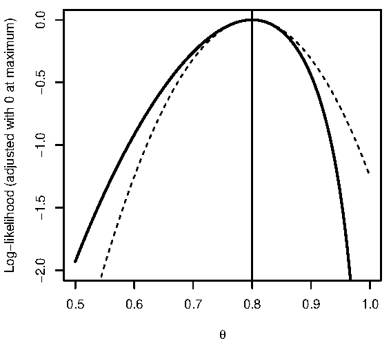

LBCI vs. Wald CI

```r
## diag.constraints=TRUE to involve the error variances in the model
## intervals.type="LB" to get the LBCI on the R2
rand2d <- tssem2(rand1, RAM=RAM3, diag.constraints=TRUE, intervals.type="LB")
summary(rand2d)
```

```
##
## Call:
## wls(Cov = pooledS, aCov = aCov, n = tssem1.obj$total.n, RAM = RAM,
##     Amatrix = Amatrix, Smatrix = Smatrix, Fmatrix = Fmatrix,
##     diag.constraints = diag.constraints, cor.analysis = cor.analysis,
##     intervals.type = intervals.type, mx.algebras = mx.algebras,
##     mxModel.Args = mxModel.Args, subset.variables = subset.variables,
##     model.name = model.name, suppressWarnings = suppressWarnings,
##     silent = silent, run = run)
##
## 95% confidence intervals: Likelihood-based statistic
## Coefficients:
##          Estimate Std.Error   lbound   ubound z value Pr(>|z|)
## s2s      0.586124        NA 0.545634 0.627353      NA       NA
## w2s      0.080237        NA 0.030172 0.128097      NA       NA
## s2w      0.085841        NA 0.035984 0.133404      NA       NA
## w2w      0.572471        NA 0.529087 0.616559      NA       NA
## w1withs1 0.380452        NA 0.336218 0.424719      NA       NA
## VarS2    0.614236        NA 0.573971 0.652410      NA       NA
## w2withs2 0.168885        NA 0.119400 0.218438      NA       NA
## VarW2    0.627516        NA 0.584755 0.667731      NA       NA
##
## mxAlgebras objects (and their 95% likelihood-based CIs):
##               lbound  Estimate    ubound
## R2_W2[1,1] 0.3322685 0.3724842 0.4152449
## R2_S2[1,1] 0.3475902 0.3857637 0.4260292
##
## Goodness-of-fit indices:
##                                            Value
## Sample size                                12906
## Chi-square of target model                     0
## DF of target model                             0
## p value of target model                        0
## Number of constraints imposed on "Smatrix"     2
## DF manually adjusted                           0
## Chi-square of independence model            3079
## DF of independence model                       6
## RMSEA                                          0
## RMSEA lower 95% CI                             0
## RMSEA upper 95% CI                             0
## SRMR                                           0
## TLI                                         -Inf
## CFI                                            1
## AIC                                            0
## BIC                                            0
## OpenMx status1: 0 ("0" or "1": The optimization is considered fine.
## Other values indicate problems.)
```

## OSMASEM: Moderator analysis

- We also want to check if the covariates help explain the heterogeneity in the data.
- We are going to illustrate how the `osmasem()` function moderates the path coefficients with a binary moderator (published vs. unpublished) and a continuous moderator (lag time between measures).

### Modelling a binary moderator

- It is reasonable to expect that published studies may differ from unpublished ones.
- MASEM makes it easy to test if the path coefficients are different.
- We create a dummy variable `Pub` with `Pub=0` for unpublished studies and `Pub=1` for published studies.
- The path coefficient, say `W2W`, is
  - $\beta_{w2w} = w2w + w2w\_1*Pub$, $w2w$ is the path coefficient when `Pub=0` and $w2w\_1$ is the *difference* of the path coefficient of `W2W` between `Pub=1` and `Pub=0`.
  - $\beta_{w2s} = w2s + w2s\_1*Pub$
  - $\beta_{s2w} = s2w + s2w\_1*Pub$
  - $\beta_{s2s} = s2s + s2s\_1*Pub$
- The results suggest that path coefficients are different for studies with and without publication, $\Delta\chi^2(4)=14.64, p=.006$.

```r
## Convert the correlation matrices into a dataframe, which is required in osmasem()
Nohe.df <- Cor2DataFrame(x=my.cor, n=df$N)

## Display the frequency table of publication status
table(df$`Publication Status`)
```

```
##
##  P  U
## 19 13
```

```r
## Create a dummy variable for publication
Pub <- ifelse(df$`Publication Status`=="P", yes=1, no=0)
table(Pub)
```

```
## Pub
##  0  1
## 13 19
```

```r
## Add Pub to the dataset
Nohe.df$data$Pub <- Pub

## Let's see how the dataset looks like
head(Nohe.df$data)
```

```
##                                        S1_W1 W2_W1 S2_W1 W2_S1 S2_S1 S2_W2
## Britt...Dawson..2005.                   0.29  0.58  0.22  0.24  0.57  0.27
## Demerouti.et.al...2004.                 0.53  0.57  0.41  0.41  0.68  0.54
## Ford..2010.                             0.35  0.75  0.32  0.26  0.74  0.30
## Hammer.et.al...2005...female.subsample  0.32  0.57  0.22  0.30  0.43  0.30
## Hammer.et.al...2005...male.subsample    0.19  0.54  0.17  0.21  0.60  0.30
## Innstrand.et.al...2008.                 0.42  0.63  0.31  0.30  0.62  0.44
##                                        C(S1_W1 S1_W1) C(W2_W1 S1_W1)
## Britt...Dawson..2005.                     0.001422479   0.0002033635
## Demerouti.et.al...2004.                   0.002076395   0.0002968500
## Ford..2010.                               0.002120708   0.0003031852
## Hammer.et.al...2005...female.subsample    0.002972616   0.0004249776
## Hammer.et.al...2005...male.subsample      0.002972616   0.0004249776
## Innstrand.et.al...2008.                   0.000311227   0.0000444943
##                                        C(S2_W1 S1_W1) C(W2_S1 S1_W1)
## Britt...Dawson..2005.                    0.0008791243   0.0008736611
## Demerouti.et.al...2004.                  0.0012832591   0.0012752845
## Ford..2010.                              0.0013106457   0.0013025009
## Hammer.et.al...2005...female.subsample   0.0018371444   0.0018257278
## Hammer.et.al...2005...male.subsample     0.0018371444   0.0018257278
## Innstrand.et.al...2008.                  0.0001923453   0.0001911500
##                                        C(S2_S1 S1_W1) C(S2_W2 S1_W1)
## Britt...Dawson..2005.                    2.047346e-04   0.0004890894
## Demerouti.et.al...2004.                  2.988513e-04   0.0007139245
## Ford..2010.                              3.052293e-04   0.0007291607
## Hammer.et.al...2005...female.subsample   4.278427e-04   0.0010220714
## Hammer.et.al...2005...male.subsample     4.278427e-04   0.0010220714
## Innstrand.et.al...2008.                  4.479427e-05   0.0001070088
##                                        C(W2_W1 W2_W1) C(S2_W1 W2_W1)
## Britt...Dawson..2005.                    0.0007981106   3.750391e-04
## Demerouti.et.al...2004.                  0.0011650033   5.474451e-04
## Ford..2010.                              0.0011898662   5.591284e-04
## Hammer.et.al...2005...female.subsample   0.0016678466   7.837355e-04
## Hammer.et.al...2005...male.subsample     0.0016678466   7.837355e-04
## Innstrand.et.al...2008.                  0.0001746202   8.205553e-05
##                                        C(W2_S1 W2_W1) C(S2_S1 W2_W1)
## Britt...Dawson..2005.                    3.671018e-04   1.042810e-04
## Demerouti.et.al...2004.                  5.358591e-04   1.522191e-04
## Ford..2010.                              5.472951e-04   1.554677e-04
## Hammer.et.al...2005...female.subsample   7.671487e-04   2.179205e-04
```

[output cut: 29 more lines]

```
## Innstrand.et.al...2008.                  8.155277e-05   0.0001912028
##                                        C(S2_S1 S2_S1) C(S2_W2 S2_S1)
## Britt...Dawson..2005.                    0.0007805638   0.0001951863
## Demerouti.et.al...2004.                  0.0011393902   0.0002849138
## Ford..2010.                              0.0011637064   0.0002909943
## Hammer.et.al...2005...female.subsample   0.0016311782   0.0004078894
## Hammer.et.al...2005...male.subsample     0.0016311782   0.0004078894
## Innstrand.et.al...2008.                  0.0001707811   0.0000427052
##                                        C(S2_W2 S2_W2) Pub
## Britt...Dawson..2005.                    0.0013981148   1
## Demerouti.et.al...2004.                  0.0020408303   1
## Ford..2010.                              0.0020843846   0
## Hammer.et.al...2005...female.subsample   0.0029217015   1
## Hammer.et.al...2005...male.subsample     0.0029217015   1
## Innstrand.et.al...2008.                  0.0003058963   1
```

## Fit model 1 (RAM1) without any moderator

- This serves as a baseline compared to models with moderators later.
- This model could be more interesting as it should be almost identical to the one in TSSEM.

```r
fit0 <- osmasem(model.name="No moderator", RAM=RAM1, data=Nohe.df)
summary(fit0)
```

```
## Summary of No moderator
##
## free parameters:
##        name  matrix row col    Estimate  Std.Error A    z value     Pr(>|z|)
## 1       w2w      A0  W2  W1  0.57247133 0.02226456    25.712220 0.000000e+00
## 2       w2s      A0  S2  W1  0.08023683 0.02484214     3.229868 1.238475e-03
## 3       s2w      A0  W2  S1  0.08584122 0.02479590     3.461912 5.363530e-04
## 4       s2s      A0  S2  S1  0.58612403 0.02079000    28.192590 0.000000e+00
## 5  w1withs1      S0  S1  W1  0.38045217 0.02256156    16.862848 0.000000e+00
## 6  w2withs2      S0  S2  W2  0.16888459 0.02523192     6.693291 2.182055e-11
## 7    Tau1_1 vecTau1   1   1 -4.30671722 0.28716838   -14.997184 0.000000e+00
## 8    Tau1_2 vecTau1   2   1 -4.73764524 0.28838623   -16.428126 0.000000e+00
## 9    Tau1_3 vecTau1   3   1 -4.94593056 0.31593252   -15.655022 0.000000e+00
## 10   Tau1_4 vecTau1   4   1 -4.95352326 0.31339092   -15.806212 0.000000e+00
## 11   Tau1_5 vecTau1   5   1 -4.92491364 0.29039423   -16.959406 0.000000e+00
## 12   Tau1_6 vecTau1   6   1 -4.39967581 0.28374629   -15.505668 0.000000e+00
##
## To obtain confidence intervals re-run with intervals=TRUE
##
## Model Statistics:
##                |  Parameters  |  Degrees of Freedom  |  Fit (-2lnL units)
##        Model:             12                    180             -300.1701
##    Saturated:             27                    165                    NA
## Independence:             12                    180                    NA
## Number of observations/statistics: 12906/192
##
## Information Criteria:
##       |  df Penalty  |  Parameters Penalty  |  Sample-Size Adjusted
## AIC:      -660.1701              -276.1701                -276.1459
## BIC:     -2003.9507              -186.5847                -224.7195
## To get additional fit indices, see help(mxRefModels)
## timestamp: 2023-02-01 10:05:01
## Wall clock time: 0.08490372 secs
## optimizer:  SLSQP
## OpenMx version number: 2.20.7
## Need help?  See help(mxSummary)
```

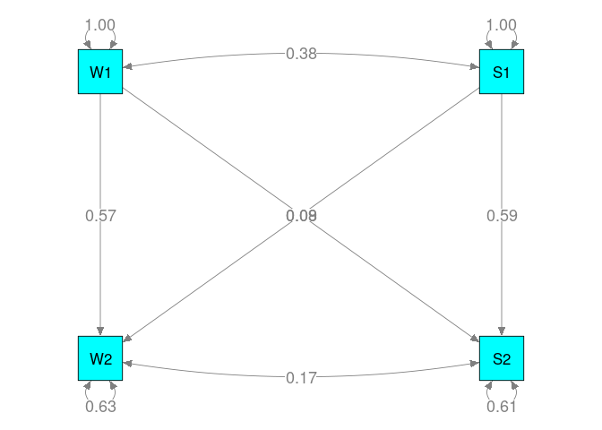

```r
plot(fit0, col="cyan")
```

## Fit a model with a moderator of “Pub”

```r
## Create a matrix to present the "Pub" moderator
## We use "Pub" to moderate the following paths:
## W1 -> W2
## W1 -> S2
## S1 -> W2
## S1 -> S2
A1 <- create.modMatrix(RAM=RAM1, output="A", mod="Pub")
A1
```

```
##    W1           S1           W2  S2
## W1 "0"          "0"          "0" "0"
## S1 "0"          "0"          "0" "0"
## W2 "0*data.Pub" "0*data.Pub" "0" "0"
## S2 "0*data.Pub" "0*data.Pub" "0" "0"
```

```r
## If we do not need to model all path coefficients, we may set them as "0".
## For example, we only want to model the path from W1 to W2.

## Create a copy of A1 for illustration
temp <- A1
temp[4, c(1, 2)] <- temp[3, 2] <- "0"
temp
```

```
##    W1           S1  W2  S2
## W1 "0"          "0" "0" "0"
## S1 "0"          "0" "0" "0"
## W2 "0*data.Pub" "0" "0" "0"
## S2 "0"          "0" "0" "0"
```

```r
## By default, we use the moderator to predict the path coefficients.
## If there are research questions to predict the correlations, we may try
S1 <- create.modMatrix(RAM=RAM1, output="S", mod="Pub")
S1
```

```
##    W1           S1           W2           S2
## W1 "0"          "0*data.Pub" "0"          "0"
## S1 "0*data.Pub" "0"          "0"          "0"
## W2 "0"          "0"          "0"          "0*data.Pub"
## S2 "0"          "0"          "0*data.Pub" "0"
```

```r
## Fit the model with Lag as a moderator: use Ax=A1 to specify A1 as the moderator
fit1 <- osmasem(model.name="Pub as a moderator", RAM=RAM1, Ax=A1, data=Nohe.df)
summary(fit1)
```

```
## Summary of Pub as a moderator
##
## free parameters:
##        name  matrix row col    Estimate  Std.Error A     z value     Pr(>|z|)
## 1       w2w      A0  W2  W1  0.54341302 0.03389313    16.0331332 0.000000e+00
## 2       w2s      A0  S2  W1  0.14617724 0.03254016     4.4922107 7.048762e-06
## 3       s2w      A0  W2  S1  0.13941113 0.03349102     4.1626426 3.145856e-05
## 4       s2s      A0  S2  S1  0.56490746 0.03155965    17.8996773 0.000000e+00
## 5  w1withs1      S0  S1  W1  0.38053285 0.02324405    16.3711921 0.000000e+00
## 6  w2withs2      S0  S2  W2  0.17000538 0.02310466     7.3580566 1.865175e-13
## 7     w2w_1      A1  W2  W1  0.05019155 0.04408051     1.1386336 2.548560e-01
## 8     w2s_1      A1  S2  W1 -0.11152071 0.03879706    -2.8744631 4.047151e-03
## 9     s2w_1      A1  W2  S1 -0.09111004 0.04019669    -2.2666055 2.341434e-02
## 10    s2s_1      A1  S2  S1  0.03645812 0.04109654     0.8871335 3.750070e-01
## 11   Tau1_1 vecTau1   1   1 -4.23658077 0.28551222   -14.8385269 0.000000e+00
## 12   Tau1_2 vecTau1   2   1 -4.77606488 0.28770244   -16.6007103 0.000000e+00
## 13   Tau1_3 vecTau1   3   1 -5.21093363 0.34016362   -15.3189035 0.000000e+00
## 14   Tau1_4 vecTau1   4   1 -5.11143125 0.33098314   -15.4431772 0.000000e+00
## 15   Tau1_5 vecTau1   5   1 -4.94663746 0.29085150   -17.0074335 0.000000e+00
## 16   Tau1_6 vecTau1   6   1 -4.63768215 0.29351737   -15.8003668 0.000000e+00
##
## To obtain confidence intervals re-run with intervals=TRUE
##
## Model Statistics:
##                |  Parameters  |  Degrees of Freedom  |  Fit (-2lnL units)
##        Model:             16                    176             -314.8082
##    Saturated:             27                    165                    NA
## Independence:             12                    180                    NA
## Number of observations/statistics: 12906/192
##
## Information Criteria:
##       |  df Penalty  |  Parameters Penalty  |  Sample-Size Adjusted
## AIC:      -666.8082              -282.8082                -282.7660
## BIC:     -1980.7270              -163.3611                -214.2074
## To get additional fit indices, see help(mxRefModels)
## timestamp: 2023-02-01 10:05:02
## Wall clock time: 0.1310687 secs
## optimizer:  SLSQP
## OpenMx version number: 2.20.7
## Need help?  See help(mxSummary)
```

```r
## Comparing the models with and without Pub
## dfs = 4 as we are testing 4 regression coefficients
anova(fit1, fit0)
```

```
##                 base   comparison ep  minus2LL  df       AIC   diffLL diffdf
## 1 Pub as a moderator         <NA> 16 -314.8082 176 -282.8082       NA     NA
## 2 Pub as a moderator No moderator 12 -300.1701 180 -276.1701 14.63812      4
##             p
## 1          NA
## 2 0.005513737
```

```r
## beta1: coefficients of (published - unpublished)
mxEval(A1, fit1$mx.fit)
```

```
##             W1          S1 W2 S2
## W1  0.00000000  0.00000000  0  0
## S1  0.00000000  0.00000000  0  0
## W2  0.05019155 -0.09111004  0  0
## S2 -0.11152071  0.03645812  0  0
```

```r
## After comparing the output, only w2s and s2w (rows 8 and 9) are statistically significant.

#        name  matrix row col    Estimate  Std.Error A     z value     Pr(>|z|)
# 1       w2w      A0  W2  W1  0.54341302 0.03389313    16.0331332 0.000000e+00
# 2       w2s      A0  S2  W1  0.14617724 0.03254016     4.4922107 7.048762e-06
# 3       s2w      A0  W2  S1  0.13941113 0.03349102     4.1626426 3.145856e-05
# 4       s2s      A0  S2  S1  0.56490746 0.03155965    17.8996773 0.000000e+00
# 5  w1withs1      S0  S1  W1  0.38053285 0.02324405    16.3711921 0.000000e+00
# 6  w2withs2      S0  S2  W2  0.17000538 0.02310466     7.3580566 1.865175e-13
# 7     w2w_1      A1  W2  W1  0.05019155 0.04408051     1.1386336 2.548560e-01
# 8     w2s_1      A1  S2  W1 -0.11152071 0.03879706    -2.8744631 4.047151e-03
# 9     s2w_1      A1  W2  S1 -0.09111004 0.04019669    -2.2666055 2.341434e-02
# 10    s2s_1      A1  S2  S1  0.03645812 0.04109654     0.8871335 3.750070e-01

## beta0: coefficients of the unpublished studies
mxEval(A0, fit1$mx.fit)
```

```
##           W1        S1 W2 S2
## W1 0.0000000 0.0000000  0  0
## S1 0.0000000 0.0000000  0  0
## W2 0.5434130 0.1394111  0  0
## S2 0.1461772 0.5649075  0  0
```

```r
## beta0 + beta1: coefficients of the published studies
mxEval(A0+A1, fit1$mx.fit)
```

```
##            W1         S1 W2 S2
## W1 0.00000000 0.00000000  0  0
## S1 0.00000000 0.00000000  0  0
## W2 0.59360457 0.04830109  0  0
## S2 0.03465653 0.60136558  0  0
```

### Modelling a continuous moderator

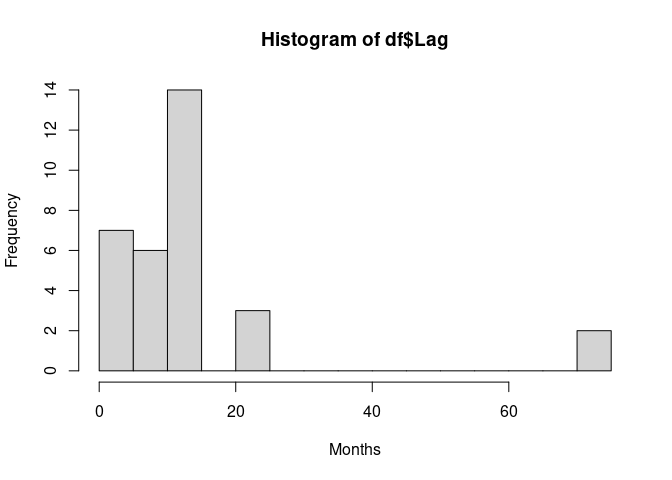

```r
hist(df$Lag, breaks=15, xlab="Months")
```

```r
## Standardize the moderator "Lag" to improve numerical stability and add it to the dataframe
Nohe.df$data$Lag <- scale(df$Lag)

head(Nohe.df$data)
```

```
##                                        S1_W1 W2_W1 S2_W1 W2_S1 S2_S1 S2_W2
## Britt...Dawson..2005.                   0.29  0.58  0.22  0.24  0.57  0.27
## Demerouti.et.al...2004.                 0.53  0.57  0.41  0.41  0.68  0.54
## Ford..2010.                             0.35  0.75  0.32  0.26  0.74  0.30
## Hammer.et.al...2005...female.subsample  0.32  0.57  0.22  0.30  0.43  0.30
## Hammer.et.al...2005...male.subsample    0.19  0.54  0.17  0.21  0.60  0.30
## Innstrand.et.al...2008.                 0.42  0.63  0.31  0.30  0.62  0.44
##                                        C(S1_W1 S1_W1) C(W2_W1 S1_W1)
## Britt...Dawson..2005.                     0.001422479   0.0002033635
## Demerouti.et.al...2004.                   0.002076395   0.0002968500
## Ford..2010.                               0.002120708   0.0003031852
## Hammer.et.al...2005...female.subsample    0.002972616   0.0004249776
## Hammer.et.al...2005...male.subsample      0.002972616   0.0004249776
## Innstrand.et.al...2008.                   0.000311227   0.0000444943
##                                        C(S2_W1 S1_W1) C(W2_S1 S1_W1)
## Britt...Dawson..2005.                    0.0008791243   0.0008736611
## Demerouti.et.al...2004.                  0.0012832591   0.0012752845
## Ford..2010.                              0.0013106457   0.0013025009
## Hammer.et.al...2005...female.subsample   0.0018371444   0.0018257278
## Hammer.et.al...2005...male.subsample     0.0018371444   0.0018257278
## Innstrand.et.al...2008.                  0.0001923453   0.0001911500
##                                        C(S2_S1 S1_W1) C(S2_W2 S1_W1)
## Britt...Dawson..2005.                    2.047346e-04   0.0004890894
## Demerouti.et.al...2004.                  2.988513e-04   0.0007139245
## Ford..2010.                              3.052293e-04   0.0007291607
## Hammer.et.al...2005...female.subsample   4.278427e-04   0.0010220714
## Hammer.et.al...2005...male.subsample     4.278427e-04   0.0010220714
## Innstrand.et.al...2008.                  4.479427e-05   0.0001070088
##                                        C(W2_W1 W2_W1) C(S2_W1 W2_W1)
## Britt...Dawson..2005.                    0.0007981106   3.750391e-04
## Demerouti.et.al...2004.                  0.0011650033   5.474451e-04
## Ford..2010.                              0.0011898662   5.591284e-04
## Hammer.et.al...2005...female.subsample   0.0016678466   7.837355e-04
## Hammer.et.al...2005...male.subsample     0.0016678466   7.837355e-04
## Innstrand.et.al...2008.                  0.0001746202   8.205553e-05
##                                        C(W2_S1 W2_W1) C(S2_S1 W2_W1)
## Britt...Dawson..2005.                    3.671018e-04   1.042810e-04
## Demerouti.et.al...2004.                  5.358591e-04   1.522191e-04
## Ford..2010.                              5.472951e-04   1.554677e-04
## Hammer.et.al...2005...female.subsample   7.671487e-04   2.179205e-04
```

[output cut: 29 more lines]

```
## Innstrand.et.al...2008.                  8.155277e-05   0.0001912028
##                                        C(S2_S1 S2_S1) C(S2_W2 S2_S1)
## Britt...Dawson..2005.                    0.0007805638   0.0001951863
## Demerouti.et.al...2004.                  0.0011393902   0.0002849138
## Ford..2010.                              0.0011637064   0.0002909943
## Hammer.et.al...2005...female.subsample   0.0016311782   0.0004078894
## Hammer.et.al...2005...male.subsample     0.0016311782   0.0004078894
## Innstrand.et.al...2008.                  0.0001707811   0.0000427052
##                                        C(S2_W2 S2_W2) Pub        Lag
## Britt...Dawson..2005.                    0.0013981148   1 -0.6794521
## Demerouti.et.al...2004.                  0.0020408303   1 -0.7711151
## Ford..2010.                              0.0020843846   0 -0.8016694
## Hammer.et.al...2005...female.subsample   0.0029217015   1 -0.1294740
## Hammer.et.al...2005...male.subsample     0.0029217015   1 -0.1294740
## Innstrand.et.al...2008.                  0.0003058963   1  0.6038301
```

```r
## Create a matrix to present "Lag" moderator
## We use Lag to moderate the following paths:
## W1 -> W2
## W1 -> S2
## S1 -> W2
## S1 -> S2
A2 <- create.modMatrix(RAM=RAM3, output="A", mod="Lag")
A2
```

```
##    W1           S1           W2  S2
## W1 "0"          "0"          "0" "0"
## S1 "0"          "0"          "0" "0"
## W2 "0*data.Lag" "0*data.Lag" "0" "0"
## S2 "0*data.Lag" "0*data.Lag" "0" "0"
```

```r
## Fit the model with Lag as a moderator
fit2 <- osmasem(model.name="Lag as a moderator", RAM=RAM1, Ax=A2, data=Nohe.df)
summary(fit2)
```

```
## Summary of Lag as a moderator
##
## free parameters:
##        name  matrix row col     Estimate  Std.Error A     z value     Pr(>|z|)
## 1       w2w      A0  W2  W1  0.573039774 0.01839766    31.1474352 0.000000e+00
## 2       w2s      A0  S2  W1  0.079844963 0.02419489     3.3000756 9.665879e-04
## 3       s2w      A0  W2  S1  0.085391026 0.02393612     3.5674541 3.604665e-04
## 4       s2s      A0  S2  S1  0.586234249 0.01962561    29.8708837 0.000000e+00
## 5  w1withs1      S0  S1  W1  0.381183701 0.02282277    16.7019031 0.000000e+00
## 6  w2withs2      S0  S2  W2  0.166974817 0.02500439     6.6778197 2.425238e-11
## 7     w2w_1      A1  W2  W1 -0.062015587 0.01850574    -3.3511550 8.047525e-04
## 8     w2s_1      A1  S2  W1 -0.025933718 0.02096724    -1.2368685 2.161359e-01
## 9     s2w_1      A1  W2  S1 -0.002382818 0.02055897    -0.1159016 9.077305e-01
## 10    s2s_1      A1  S2  S1 -0.027809761 0.01974172    -1.4086798 1.589299e-01
## 11   Tau1_1 vecTau1   1   1 -4.276381062 0.28720202   -14.8898017 0.000000e+00
## 12   Tau1_2 vecTau1   2   1 -5.261036068 0.32310513   -16.2827376 0.000000e+00
## 13   Tau1_3 vecTau1   3   1 -5.048387485 0.32015074   -15.7687828 0.000000e+00
## 14   Tau1_4 vecTau1   4   1 -5.039816726 0.31967923   -15.7652306 0.000000e+00
## 15   Tau1_5 vecTau1   5   1 -5.074951111 0.29424552   -17.2473351 0.000000e+00
## 16   Tau1_6 vecTau1   6   1 -4.397726437 0.28288197   -15.5461533 0.000000e+00
##
## To obtain confidence intervals re-run with intervals=TRUE
##
## Model Statistics:
##                |  Parameters  |  Degrees of Freedom  |  Fit (-2lnL units)
##        Model:             16                    176             -323.6921
##    Saturated:             27                    165                    NA
## Independence:             12                    180                    NA
## Number of observations/statistics: 12906/192
##
## Information Criteria:
##       |  df Penalty  |  Parameters Penalty  |  Sample-Size Adjusted
## AIC:      -675.6921              -291.6921                -291.6499
## BIC:     -1989.6109              -172.2449                -223.0913
## To get additional fit indices, see help(mxRefModels)
## timestamp: 2023-02-01 10:05:02
## Wall clock time: 0.1711533 secs
## optimizer:  SLSQP
## OpenMx version number: 2.20.7
## Need help?  See help(mxSummary)
```

```r
## Comparing the models with and without the covariate
anova(fit2, fit0)
```

```
##                 base   comparison ep  minus2LL  df       AIC   diffLL diffdf
## 1 Lag as a moderator         <NA> 16 -323.6921 176 -291.6921       NA     NA
## 2 Lag as a moderator No moderator 12 -300.1701 180 -276.1701 23.52199      4
##              p
## 1           NA
## 2 9.957486e-05
```

```r
## Effect of w2w when Lag is at the mean value
Mean <- mxEval(w2w, fit2$mx.fit)
Mean
```

```
##           [,1]
## [1,] 0.5730398
```

```r
## Effect of w2w when Lag is at +1 SD as Lag is standardized
PlusSD <- mxEval(w2w + w2w_1, fit2$mx.fit)
PlusSD
```

```
##           [,1]
## [1,] 0.5110242
```

```r
## Effect of w2w when Lag is at -1 SD as Lag is standardized
MinSD <- mxEval(w2w - w2w_1, fit2$mx.fit)
MinSD
```

```
##           [,1]
## [1,] 0.6350554
```

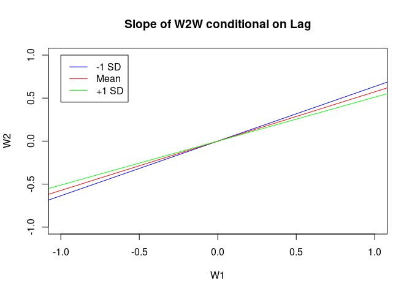

```r
## Show the effect graphically
plot(x=NULL, y=NULL, xlim=c(-1,1), ylim=c(-1,1), xlab="W1", ylab="W2", main="Slope of W2W conditional on Lag")
abline(a=0, b=MinSD, col="blue")
abline(a=0, b=Mean, col="red")
abline(a=0, b=PlusSD, col="green")
legend(-1, 1, c("-1 SD", "Mean", "+1 SD"), col=c("blue", "red", "green"), lty=c(1,1,1))
```

### Handling missing data in moderator analysis

- `osmasem` assumes there is no missing data in the moderators.
- When there are missing data in the moderators, we must remove them before the analyses. Moreover, we must ensure that the same data are used in model comparisons.

```r
## Make a copy for illustrations
Nohe.miss <- Nohe.df

## Create missing values in the first two studies to illustrate the issues
Nohe.miss$data$Lag[c(1, 2)] <- NA

head(Nohe.miss$data)
```

```
##                                        S1_W1 W2_W1 S2_W1 W2_S1 S2_S1 S2_W2
## Britt...Dawson..2005.                   0.29  0.58  0.22  0.24  0.57  0.27
## Demerouti.et.al...2004.                 0.53  0.57  0.41  0.41  0.68  0.54
## Ford..2010.                             0.35  0.75  0.32  0.26  0.74  0.30
## Hammer.et.al...2005...female.subsample  0.32  0.57  0.22  0.30  0.43  0.30
## Hammer.et.al...2005...male.subsample    0.19  0.54  0.17  0.21  0.60  0.30
## Innstrand.et.al...2008.                 0.42  0.63  0.31  0.30  0.62  0.44
##                                        C(S1_W1 S1_W1) C(W2_W1 S1_W1)
## Britt...Dawson..2005.                     0.001422479   0.0002033635
## Demerouti.et.al...2004.                   0.002076395   0.0002968500
## Ford..2010.                               0.002120708   0.0003031852
## Hammer.et.al...2005...female.subsample    0.002972616   0.0004249776
## Hammer.et.al...2005...male.subsample      0.002972616   0.0004249776
## Innstrand.et.al...2008.                   0.000311227   0.0000444943
##                                        C(S2_W1 S1_W1) C(W2_S1 S1_W1)
## Britt...Dawson..2005.                    0.0008791243   0.0008736611
## Demerouti.et.al...2004.                  0.0012832591   0.0012752845
## Ford..2010.                              0.0013106457   0.0013025009
## Hammer.et.al...2005...female.subsample   0.0018371444   0.0018257278
## Hammer.et.al...2005...male.subsample     0.0018371444   0.0018257278
## Innstrand.et.al...2008.                  0.0001923453   0.0001911500
##                                        C(S2_S1 S1_W1) C(S2_W2 S1_W1)
## Britt...Dawson..2005.                    2.047346e-04   0.0004890894
## Demerouti.et.al...2004.                  2.988513e-04   0.0007139245
## Ford..2010.                              3.052293e-04   0.0007291607
## Hammer.et.al...2005...female.subsample   4.278427e-04   0.0010220714
## Hammer.et.al...2005...male.subsample     4.278427e-04   0.0010220714
## Innstrand.et.al...2008.                  4.479427e-05   0.0001070088
##                                        C(W2_W1 W2_W1) C(S2_W1 W2_W1)
## Britt...Dawson..2005.                    0.0007981106   3.750391e-04
## Demerouti.et.al...2004.                  0.0011650033   5.474451e-04
## Ford..2010.                              0.0011898662   5.591284e-04
## Hammer.et.al...2005...female.subsample   0.0016678466   7.837355e-04
## Hammer.et.al...2005...male.subsample     0.0016678466   7.837355e-04
## Innstrand.et.al...2008.                  0.0001746202   8.205553e-05
##                                        C(W2_S1 W2_W1) C(S2_S1 W2_W1)
## Britt...Dawson..2005.                    3.671018e-04   1.042810e-04
## Demerouti.et.al...2004.                  5.358591e-04   1.522191e-04
## Ford..2010.                              5.472951e-04   1.554677e-04
## Hammer.et.al...2005...female.subsample   7.671487e-04   2.179205e-04
```

[output cut: 29 more lines]

```
## Innstrand.et.al...2008.                  8.155277e-05   0.0001912028
##                                        C(S2_S1 S2_S1) C(S2_W2 S2_S1)
## Britt...Dawson..2005.                    0.0007805638   0.0001951863
## Demerouti.et.al...2004.                  0.0011393902   0.0002849138
## Ford..2010.                              0.0011637064   0.0002909943
## Hammer.et.al...2005...female.subsample   0.0016311782   0.0004078894
## Hammer.et.al...2005...male.subsample     0.0016311782   0.0004078894
## Innstrand.et.al...2008.                  0.0001707811   0.0000427052
##                                        C(S2_W2 S2_W2) Pub        Lag
## Britt...Dawson..2005.                    0.0013981148   1         NA
## Demerouti.et.al...2004.                  0.0020408303   1         NA
## Ford..2010.                              0.0020843846   0 -0.8016694
## Hammer.et.al...2005...female.subsample   0.0029217015   1 -0.1294740
## Hammer.et.al...2005...male.subsample     0.0029217015   1 -0.1294740
## Innstrand.et.al...2008.                  0.0003058963   1  0.6038301
```

```r
## Fit the model with Lag as a moderator
## It does not work because of the missing data
fit3a <- osmasem(model.name="Lag as a moderator with NA", RAM=RAM1, Ax=A2, data=Nohe.miss)
```

```
## <simpleError in runHelper(model, frontendStart, intervals, silent, suppressWarnings,     unsafe, checkpoint, useSocket, onlyFrontend, useOptimizer,     beginMessage): Lag as a moderator with NA.data: NA in definition variable 'Lag'>
```

```r
## Create a variable to indicate which should be included (TRUE)
subset.rows <- c(!is.na(Nohe.miss$data$Lag))
subset.rows
```

```
##  [1] FALSE FALSE  TRUE  TRUE  TRUE  TRUE  TRUE  TRUE  TRUE  TRUE  TRUE  TRUE
## [13]  TRUE  TRUE  TRUE  TRUE  TRUE  TRUE  TRUE  TRUE  TRUE  TRUE  TRUE  TRUE
## [25]  TRUE  TRUE  TRUE  TRUE  TRUE  TRUE  TRUE  TRUE
```